# Stock Market EDA Project Documentation

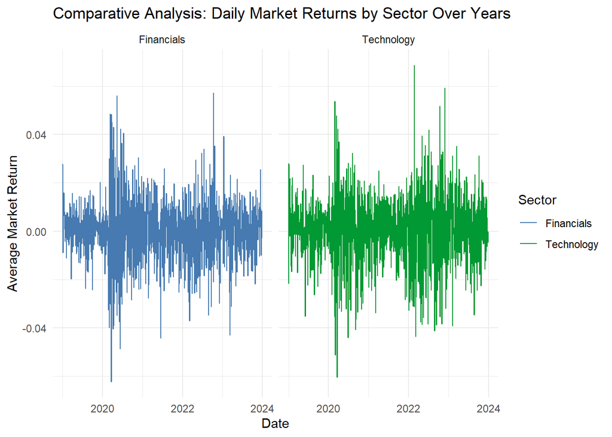

```r
# 4 Trend of Average Daily Market Return Over the Years
stock_market_data %>% group_by(Date, Sector) %>%
  summarise(Average_Market_Return = mean(Market_Return)) %>%
  ggplot(aes(x=Date, y=Average_Market_Return, color=Sector))+
  geom_line() +
  scale_color_manual(values =
                       c("Financials" = "#467ab0",
                         "Technology" = "#009933")) +
  labs(title = "Comparative Analysis: Daily Market Returns by Sector Over Years", x="Date",y="Average Market Return") +
  facet_wrap( ~ Sector) +
  theme_minimal()
```

1. **Average Close Price Evolution Over Time for each Sectors**
- The Technology sector has shown a significant upward trend in average close price, with a noticeable dip and recovery around 2022.
- The Financials sector exhibits a more stable and gradual increase in average close price over time, without the same level of volatility observed in the Technology sector.
2. **Trading Volume Trends by Sector Over Time**
- Trading volume in the Technology sector is highly variable, with distinct spikes suggesting periods of intense trading activity.
- The Financials sector shows more subdued volume fluctuations, indicating less erratic trading activity.
3. **Volatility Patterns Across Sectors Over Time**
- Both sectors experienced heightened volatility around 2020, which aligns with the market’s response to the COVID-19 pandemic.
- The Technology sector has continued to experience high volatility post-2020, with some stabilization but still considerable fluctuations.
- The Financials sector’s volatility seems to have decreased more steadily after 2020, maintaining lower levels relative to Technology.
4. **Comparative Analysis: Daily Market Returns by Sector Over Years**
- Market returns for both sectors fluctuate around zero, with the Technology sector exhibiting a wider range of returns, suggesting higher risk and potential for reward.
- The Financials sector shows a tighter clustering of daily returns, indicating less variability and potentially lower risk.

The upward trend in the average close price of the Technology sector reflects a robust growth trajectory but comes with higher volatility and wider fluctuations in market returns. In contrast, the Financials sector appears more stable with less dramatic growth in close prices, lower trading volumes, and more contained daily market returns.These trends can inform investors about the risk profiles of each sector Technology as growth-oriented but more volatile, and Financials as potentially more stable but with less aggressive growth. The specific spikes and dips could correlate with industry-specific events or broader economic changes, warranting a closer analysis for precise causes.

**Time series Analysis on a Stock Level**

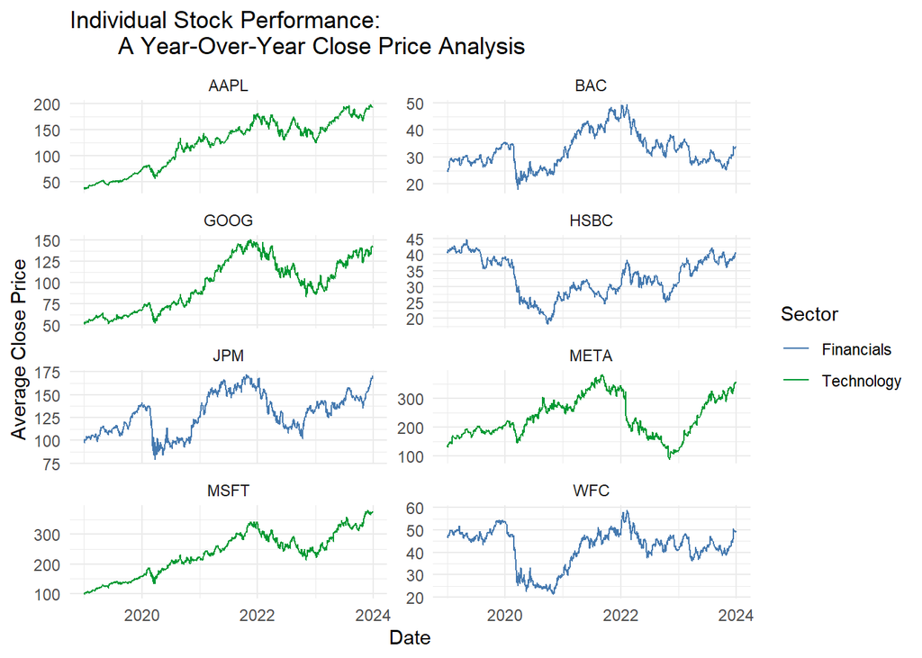

```r
# On a Stock level
# 1 Trend of Average Close Price Over the Years for each stocks
stock_market_data %>% group_by(Date,Sector,Symbol) %>%
  summarise(Average_Close = mean(Close)) %>%
  ggplot(aes(x=Date, y=Average_Close, color=Sector)) +
  geom_line() +
  scale_color_manual(values =
                       c("Financials" = "#467ab0",
                         "Technology" = "#009933")) +
  labs(title = "Individual Stock Performance:
       A Year-Over-Year Close Price Analysis",
       x="Date",y="Average Close Price") +
  facet_wrap(~ Symbol, scales = "free_y", ncol = 2 ) +
  theme_minimal()
```

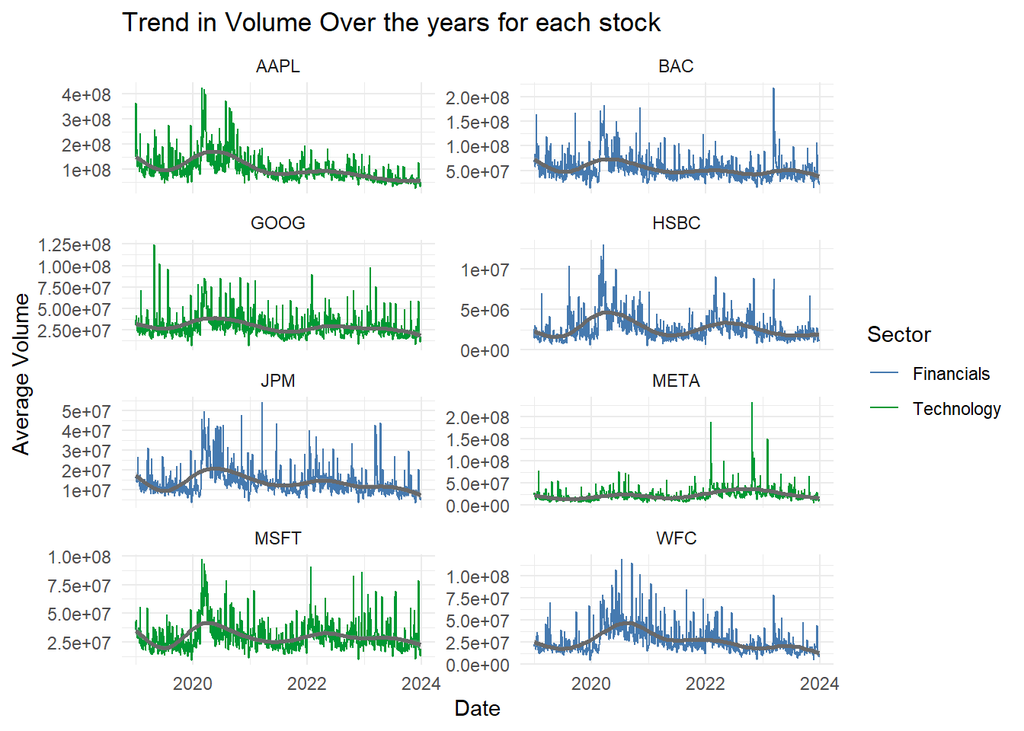

```r
# 2 Trend of Average Volume Over the Years
stock_market_data %>% group_by(Date, Sector, Symbol) %>%
  summarise(Average_Volume = mean(Volume)) %>%
  ggplot(aes(x=Date, y=Average_Volume, color=Sector)) +
  geom_line() +
  geom_smooth( size=0.9, color="#696969") +
  scale_color_manual(values =
                       c("Financials" = "#467ab0",
                         "Technology" = "#009933")) +
  labs(title = "Trend in Volume Over the years for each stock",
       x="Date",y="Average Volume") +
  facet_wrap( ~ Symbol, scales = "free_y", ncol = 2) +
  theme_minimal()
```

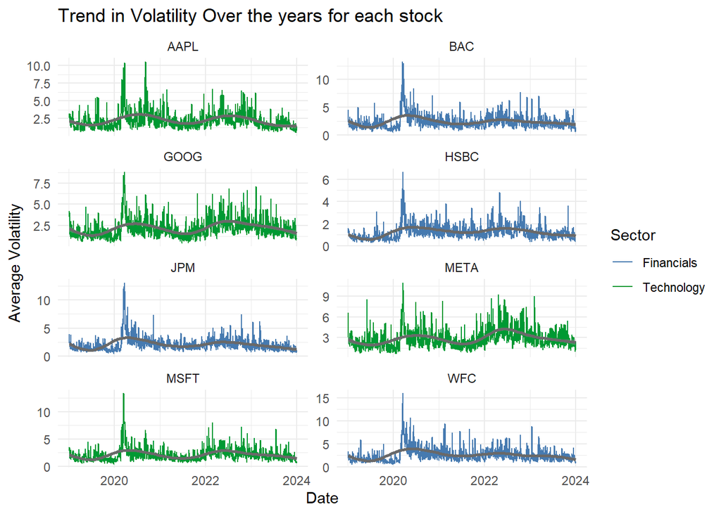

```r
# 3 Trend of Average Volatility Over the Years
stock_market_data %>% group_by(Date, Sector, Symbol) %>%
  summarise(Average_Volatility = mean(Volatility)) %>%
  ggplot(aes(x=Date, y=Average_Volatility, color=Sector)) +
  geom_line() +
  geom_smooth( size=0.9, color="#696969") +
  scale_color_manual(values =
                       c("Financials" = "#467ab0",
                         "Technology" = "#009933")) +
  labs(title = "Trend in Volatility Over the years for each stock",
       x="Date",y="Average Volatility") +
  facet_wrap( ~ Symbol, scales = "free_y", ncol = 2) +
  theme_minimal()
```

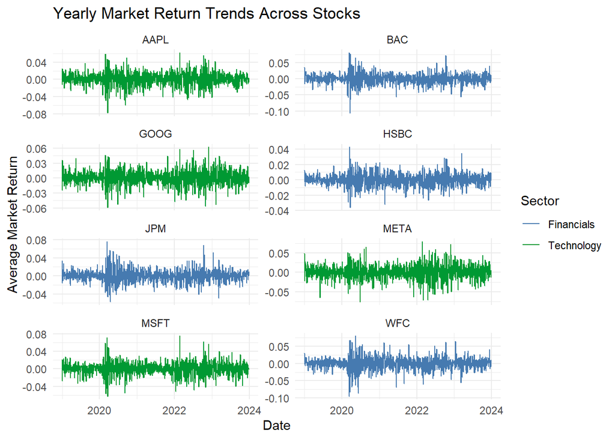

```r
# 4 Trend of Average Daily Market Return Over the Years
stock_market_data %>% group_by(Date, Sector, Symbol) %>%
  summarise(Average_Market_Return = mean(Market_Return)) %>%
  ggplot(aes(x=Date, y=Average_Market_Return, color=Sector)) +
  geom_line() +
  scale_color_manual(values =
                       c("Financials" = "#467ab0",
                         "Technology" = "#009933")) +
  labs(title = "Yearly Market Return Trends Across Stocks",
       x="Date",y="Average Market Return") +
  facet_wrap( ~ Symbol,scales = "free_y", ncol = 2) +
  theme_minimal()
```

###### **Outcome**

The application of this methodology yielded comprehensive insights into the stock market’s behaviour, highlighting differences between sectors, identifying key trends and anomalies, and uncovering the correlation between various market indicators. This facilitated a nuanced understanding of market dynamics, essential for informed decision-making and strategic investment planning.

## Challenges and Solutions

#### Challenges

- **Data Complexity and Volume**: The vast amount and intricacy of stock market data initially made management and manipulation challenging.
- **Outlier Detection and Handling**: Identifying the best approach to outliers was critical, as they could skew analysis results if not properly addressed.
- **Interpreting Correlations**: Understanding the implications of various correlations between market variables required careful consideration and contextual knowledge.
- **Technical Issues with R Studio**: Frequent hangs and slowdowns in R Studio, likely due to the extensive operations and code running simultaneously, disrupted the smooth progress of analysis.
- **Variable Selection Conflict**: Deciding on the most informative variables for analysis and those that would best answer my research questions was a recurring dilemma.

#### Solutions

- **Efficient Data Handling**: Leveraged powerful R packages like dplyr and tidyverse for effective data management.
- **Strategic Approach to Outliers**: Chose to retain outliers, viewing them as meaningful extremes that could signify pivotal market events.
- **In-depth Correlation Analysis**: Supplemented statistical findings with market research to contextualize correlation insights accurately.
- **Technical Workarounds**: Implemented measures to mitigate technical issues, such as optimizing code for efficiency and breaking down analysis into smaller, manageable segments.
- **Iterative Variable Selection**: Adopted an iterative approach to variable selection, continuously refining the choices based on the evolving understanding of the dataset and research objectives.

## Conclusion

This exploratory data analysis journey through historical stock market data has yielded comprehensive insights into the behaviours and dynamics of the technology and financial sectors. Key takeaways include:

- **Sectoral Differences**: The analysis highlighted distinct patterns in trading volume, market returns, and volatility between the technology and financial sectors.
- **Market Dynamics**: Seasonal and time series analysis revealed how external events and inherent market forces shape trading behaviours and stock valuations over time.
- **Correlation Insights**: The exploration of correlations between various financial metrics unveiled complex relationships that govern market movements.

The reliability and reproducibility of this analysis are underpinned by systematic data preprocessing, meticulous methodological application, and transparent documentation of the analytically process. Future inquiries spurred by this analysis promise further exploration into the intricacies of market behavior, offering opportunities for deeper insights and refined investment strategies.